# multivariate models

Hunt Jones

2/10/2022

For this assignment will be analyzing data on the Vegetation and Environment in Dutch Dune Meadows.

To import the data and read the metadata run the following:

```r
library(vegan)
data(dune)
data(dune.env)
?dune
?dune.env
```

1. Conduct an indirect ordination on the dune plant community. Specifically, visually examine a NMDS plot using the bray-curtis distance metric. Below is some code to help you develop a potential plot that emphasizes the role of the environmental variable “Moisture”. Describe how you interpret the graphic. What is the goal of creating such a plot? Does this analysis suggest any interesting findings with respect to the dune vegetation?

   ```r
   dune_mds <- metaMDS(dune, distance = "bray")
   ```

   ```
   ## *** Solution reached
   ```

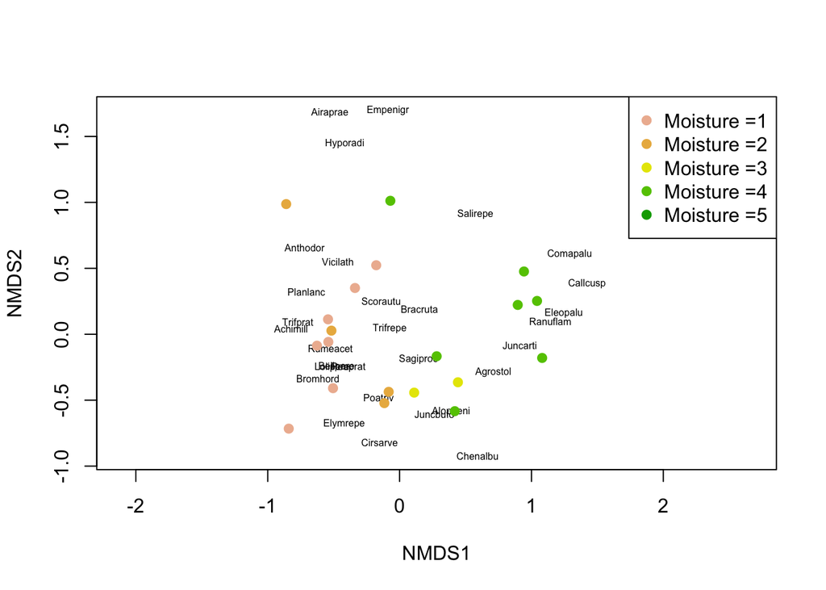

   ```r
   dune.env$Moisture <- as.numeric(dune.env$Moisture)


   plot(dune_mds, type='n')
   text(dune_mds, 'sp', cex=.5)
   # generate vector of colors
   color_vect = rev(terrain.colors(6))[-1]
   points(dune_mds, 'sites', pch=19,
          col=color_vect[dune.env$Moisture])
   legend('topright', paste("Moisture =", 1:5, sep=''),
          col=color_vect, pch=19)
   ```

   ```r
   # Based on this graph, it appears that sites that are more similar to one
   # another tend to have the same moisture, where dryer sites are similar to
   # other dry sites and wetter sites are similar to other wet sites. What this
   # means is that the plant community is largely determined by moisture.
   ```

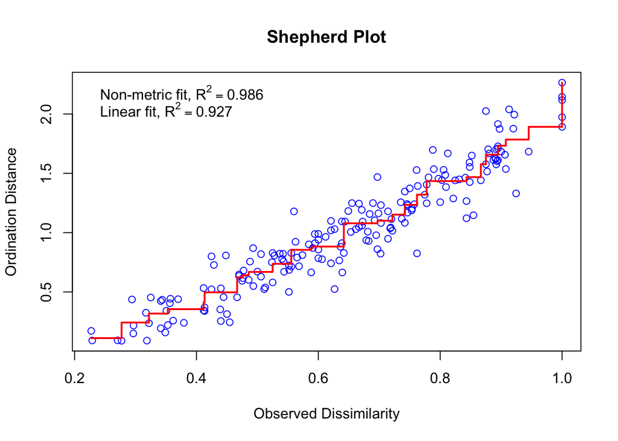

```r
stressplot(dune_mds, main = "Shepherd Plot")
```

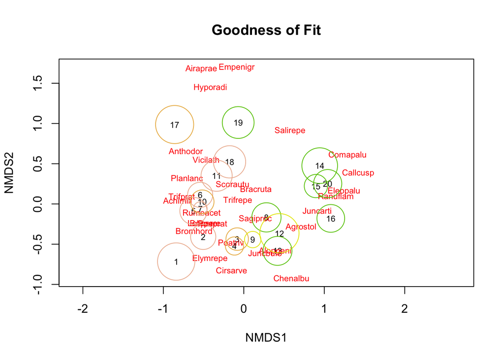

```r
gof=goodness(dune_mds)
plot(dune_mds, type="t", main="Goodness of Fit")
points(dune_mds, display="sites", cex=gof*200, col=color_vect[dune.env$Moisture])
```

2. Carry out a direct ordination using CCA in order to test any potential hypotheses that you developed after examining the MDS plot. Specifically, carry out a test of the entire model (i.e., including all constrained axes) and also carry out tests at the scale of individual explanatory variables you included in your model if you included more than one variable. Plot your results.

```r
library(vegan)
dune_cca <- cca(dune)
dune_cca
```

```
## Call: cca(X = dune)
##
##               Inertia Rank
## Total           2.115
## Unconstrained   2.115   19
## Inertia is scaled Chi-square
##
## Eigenvalues for unconstrained axes:
##    CA1    CA2    CA3    CA4    CA5    CA6    CA7    CA8
## 0.5360 0.4001 0.2598 0.1760 0.1448 0.1079 0.0925 0.0809
## (Showing 8 of 19 unconstrained eigenvalues)
```